# BB 16S MB Final Analyses

Load required packages.

```r
require(phyloseq)
 require(parallelDist)
require(ggplot2)
  require(randomForest)
require(Boruta)
  require(phyloseq)
require(stats)
  require(dplyr)
require(readr)
  require(pheatmap)
require(tidyverse)
  require(micrUBIfuns)
require(circlize)
  require(phylosmith)
require(phangorn)
  require(gridExtra)
require(pairwiseAdonis)
  require(car)
require(phyloseq)
```

Load necessary files from Dada2 processing script.

```r
load("/Users/gordoncuster/Desktop/Git_Projects/BeeBread/Data/16S/DADA2outputs/dada2_outputs_16S_BeeBread_wtree.RData")
```

Read in metadata

```r
metadata<-read.csv("/Users/gordoncuster/Desktop/Git_Projects/BeeBread/Data/BB_sample-metadata.txt", sep = "\t")
rownames(metadata)<-metadata$X
metadata$Region_Site<-paste( metadata$Region, metadata$Site, sep = "")
metadata$Treatment_Site<-paste( metadata$Treatment, metadata$Site, sep = "")
```

Convert files to correct format for phyloseq object and then rename samples in OTU table to match the format of the metadata file. Create phyloseq object and root phylogenetic tree for usage with distance metrics (e.g., Unifrac).

```r
#assign object type to merge into phyloseq object
md<-sample_data(metadata)
otu<-otu_table(seqtab.nochim, taxa_are_rows = F)
tax_tab<-tax_table(taxa)
#check sample names of both otu table and metadata
#remove .fastq.gz from otu table names
sample_names(otu)<-str_split(sample_names(otu), pattern = ".fastq.gz", simplify = T) [,1]
#since they match, you can create the phyloseq object
bb16S_orig<-phyloseq(md, otu, tax_tab, fitGTR$tree)

#root tree for distance metrics like unifrac
set.seed(11)
phy_tree(bb16S_orig)<-root(phy_tree(bb16S_orig), sample(taxa_names(bb16S_orig), 1), resolve.root = TRUE)
is.rooted(phy_tree(bb16S_orig))
```

#Pre-processing. Rename OTU IDS to something more manageable. We save the ASCV sequences in case we need them later (e.g., BLASTN searches). Create Bacterial and Archaeal phyloseq objects, but first we remove Chloroplasts.

```r
#Extract original IDs for future reference.
seq_df_w_OTUID<-data.frame(OTUID = 1:ntaxa(bb16S_orig), Sequence = taxa_names(bb16S_orig))
taxa_names(bb16S_orig)<-paste("OTU_" , 1:ntaxa(bb16S_orig), sep = "")


#remove chloroplast
#978 chloroplast or mitochondrial taxa
bb16S_orig_nc<-subset_taxa(bb16S_orig, Family!= "Mitochondria" | is.na(Family) & Order!="Chloroplast" | is.na(Order))


#1337 bacterial taxa - 9 non-bacteria removed.
bb16S_bac<-subset_taxa(bb16S_orig_nc, Kingdom == "Bacteria")
#9 archaea
bb16S_arch<-subset_taxa(bb16S_orig_nc, Kingdom == "Archaea")
```

Remove control samples as there is only as single replicate of each.

```r
ps_wo_control<-subset_samples(bb16S_bac, Treatment != "none")
```

```
vegan::rarecurve(data.frame(otu_table(ps_wo_control)), step=50, cex=0.5, main = "Rarefaction Curve", ylab="Richness", xlab="Read Depth")
```

```r
set.seed(11)
sort(sample_sums(ps_wo_control))
summary(sample_sums(ps_wo_control))
sd(sample_sums(ps_wo_control))
bb16S_bac_rarefy<-rarefy_even_depth(ps_wo_control, sample.size = 1100, rngseed = 14, trimOTUs = T)
#517 otus were removed during rarefaction.

#To move forward, we can hellinger transform and go from there.
bb16S_bac_hellinger<-transform_sample_counts(ps_wo_control, function(x) sqrt(x / sum(x)))

#maximum liklihood point estimates
bb16S_bac_ML<- transform_sample_counts(ps_wo_control, function(x) x / sum(x))
```

#Alpha Diversity

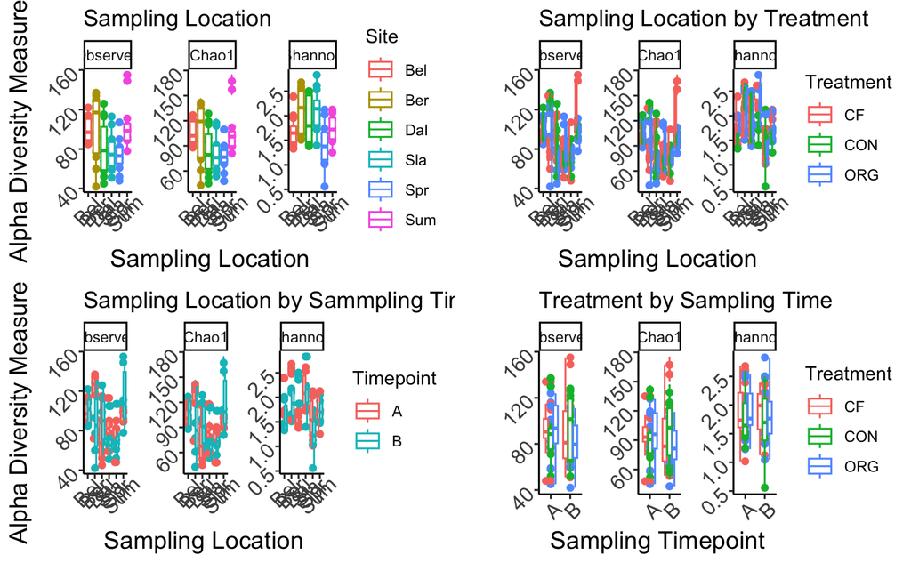

```r
sf2a <- plot_richness(bb16S_bac_rarefy, x = "Site", measures = c("Shannon", "Observed", "Chao1"), color = "Site") + geom_boxplot() + ggtitle("Sampling Location") + theme_classic()  + xlab("Sampling Location")  + theme(axis.text=element_text(size=12, angle = 45, hjust = 0.75),
        axis.title=element_text(size=14))

sf2b <- plot_richness(bb16S_bac_rarefy, x = "Site", measures = c("Shannon", "Observed", "Chao1"), color = "Treatment") + geom_boxplot() + ggtitle("Sampling Location by Treatment") + theme_classic() + ylab("") + xlab("Sampling Location") +theme(axis.text=element_text(size=12, angle = 45, hjust = 0.75),
        axis.title=element_text(size=14))

sf2c <-plot_richness(bb16S_bac_rarefy, x = "Site", measures = c("Shannon", "Observed", "Chao1"), color = "Timepoint") + geom_boxplot() + ggtitle("Sampling Location by Sammpling Time") + theme_classic() + xlab("Sampling Location")  +theme(axis.text=element_text(size=12, angle = 45, hjust = 0.75),
        axis.title=element_text(size=14))

sf2d <-plot_richness(bb16S_bac_rarefy, x = "Timepoint", measures = c("Shannon", "Observed", "Chao1"), color = "Treatment") + geom_boxplot() + ggtitle("Treatment by Sampling Time") + theme_classic() + ylab("") + xlab("Sampling Timepoint")  +theme(axis.text=element_text(size=12, angle = 45, hjust =0.75),
        axis.title=element_text(size=14))

sf2 <- grid.arrange(sf2a, sf2b, sf2c, sf2d)
```

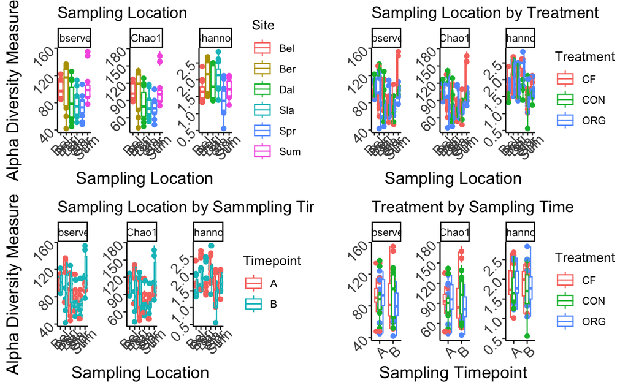

```r
plot(sf2)
```

Calculate alpha diversity metrics

```r
#create alpha diversity table and prep data to include grouping columns
richness_BB16S_bac<-estimate_richness(bb16S_bac_rarefy, measures = c("Shannon", "Observed", "Chao1"))
#add metadata
richness_BB16S_bac$Site<-sample_data(bb16S_bac_rarefy)$Site
richness_BB16S_bac$Timepoint<-sample_data(bb16S_bac_rarefy)$Timepoint
richness_BB16S_bac$Treatment<-sample_data(bb16S_bac_rarefy)$Treatment
richness_BB16S_bac$Treatment_Timepoint<-sample_data(bb16S_bac_rarefy)$Treatment_Timepoint
```

Tests of Shannon diversity

```r
mod<-aov(Shannon ~ Site * Treatment * Timepoint, data = richness_BB16S_bac)
#residuals look fine.
shapiro.test(mod$residuals)
```

```
    Shapiro-Wilk normality test

data:  mod$residuals
W = 0.98181, p-value = 0.3836
```

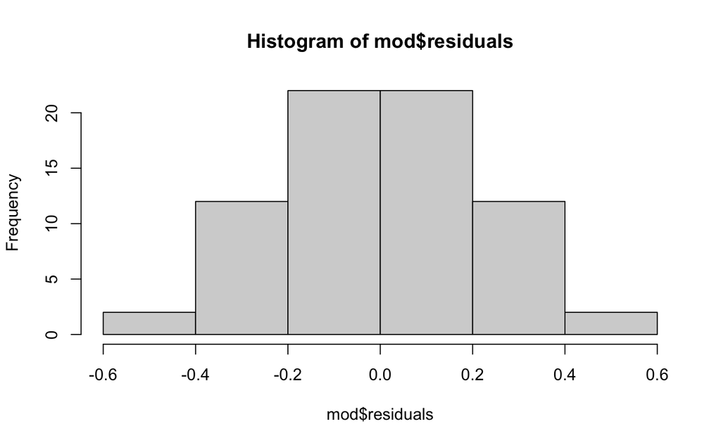

```r
hist(mod$residuals)
```

```r
summary(mod)
```

```
                         Df Sum Sq Mean Sq F value   Pr(>F)
Site                      5  4.759  0.9518   9.091 1.17e-05 ***
Treatment                 2  0.274  0.1371   1.310 0.282475
Timepoint                 1  0.038  0.0383   0.366 0.549137
Site:Treatment           10  1.551  0.1551   1.481 0.186660
Site:Timepoint            5  3.412  0.6823   6.517 0.000207 ***
Treatment:Timepoint       2  0.017  0.0084   0.080 0.923465
Site:Treatment:Timepoint 10  1.555  0.1555   1.485 0.185198
Residuals                36  3.769  0.1047
---
Signif. codes:  0 ‘***’ 0.001 ‘**’ 0.01 ‘*’ 0.05 ‘.’ 0.1 ‘ ’ 1
```

Tests of Chao 1

```r
mod<-aov(Chao1 ~ Site * Treatment * Timepoint, data = richness_BB16S_bac)
#residuals look fine.
shapiro.test(mod$residuals)
```

```
    Shapiro-Wilk normality test

data:  mod$residuals
W = 0.98627, p-value = 0.6242
```

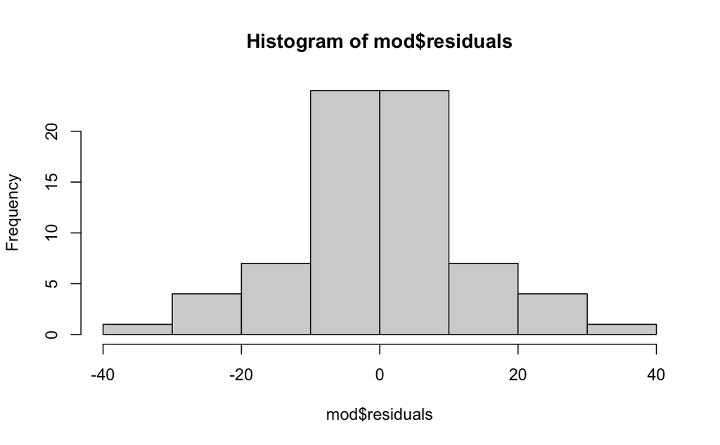

```r
hist(mod$residuals)
```

```r
summary(mod)
```

```
                         Df Sum Sq Mean Sq F value   Pr(>F)
Site                      5  12611  2522.2   7.464 6.84e-05 ***
Treatment                 2    570   285.1   0.844  0.43851
Timepoint                 1      0     0.1   0.000  0.98873
Site:Treatment           10  10084  1008.4   2.984  0.00769 **
Site:Timepoint            5   6473  1294.5   3.831  0.00694 **
Treatment:Timepoint       2   1106   552.8   1.636  0.20893
Site:Treatment:Timepoint 10   8527   852.7   2.523  0.02040 *
Residuals                36  12165   337.9
---
Signif. codes:  0 ‘***’ 0.001 ‘**’ 0.01 ‘*’ 0.05 ‘.’ 0.1 ‘ ’ 1
```

Tests of Observed - unique taxa in a sample.

```r
#ANOVA and Tukey's PW comparisons
#Run a full 3 way ANOVA with interactions
mod<-aov(Observed ~ Site * Treatment * Timepoint, data = richness_BB16S_bac)
#residuals look fine.
shapiro.test(mod$residuals)
summary(mod)
hist(mod$residuals)

leveneTest(Observed ~ Site, data = richness_BB16S_bac)
leveneTest(Observed ~ Treatment, data = richness_BB16S_bac)
leveneTest(Observed ~ Timepoint, data = richness_BB16S_bac)

#Summary of model shows site and timepoint to be a significant predictor as well as the site interaction terms.
TukeyHSD(mod, "Site")
plot(TukeyHSD(mod, "Site"), las=1, cex.axis = 0.4)
```

#Beta diversity

```r
#extract data from phyloseq object
tab_adonis<-data.frame(otu_table(bb16S_bac_ML))
sd_adonis<-data.frame(sample_data(bb16S_bac_ML))
sd_adonis$Treatment <-as.factor(sd_adonis$Treatment)
sd_adonis$Site <-as.factor(sd_adonis$Site)
dist_w<-phyloseq::distance(bb16S_bac_ML, method =  "wunifrac")
dist_uw<-phyloseq::distance(bb16S_bac_ML, method =  "unifrac")

#full model with no strata arguemnt. Essentially the effect of each main effect without controlling for any potential groups.

#Table S2
#weighted
adonis2(dist_w ~  Site * Treatment * Timepoint, data= sd_adonis, permutations = 1000)
#unweighted
adonis2(dist_uw ~  Site * Treatment * Timepoint, data= sd_adonis, permutations = 1000)

#with strata argument
adonis2(dist_w ~  Site * Treatment * Timepoint, data= sd_adonis, strata = sd_adonis$Site, permutations = 1000)
adonis2(dist_uw ~  Site * Treatment * Timepoint, data= sd_adonis, strata = sd_adonis$Site, permutations = 1000)


##PW adonis w/ strata = site
pairwiseAdonis::pairwise.adonis2(dist_uw ~ Treatment + Timepoint, strata = "Site",  data= sd_adonis, nperm = 1000)
pairwiseAdonis::pairwise.adonis2(dist_w ~ Treatment + Timepoint, strata = "Site",  data= sd_adonis, nperm = 1000)
```

Ordinations

```r
#weighted Unifrac
ord_nmds<-ordinate(physeq = bb16S_bac_ML, method = "NMDS", distance = "wunifrac")
```

```
*** Best solution repeated 3 times
```

```r
ord_nmds$stress
```

```
[1] 0.05077733
```

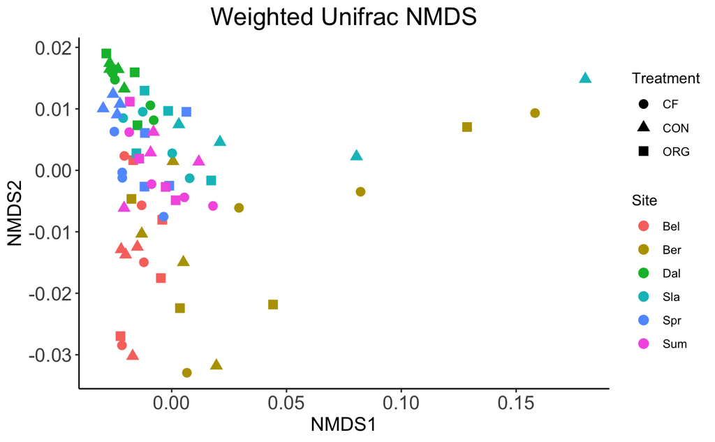

```r
plot_ordination(physeq = bb16S_bac_ML, ordination = ord_nmds, type = "Samples", color = "Site", shape = "Treatment" ) + theme_classic() + ggtitle("Weighted Unifrac NMDS") + theme(plot.title = element_text(hjust = 0.5, size = 18)) + geom_point(size = 3) + theme(axis.text = element_text(size = 14), axis.title=element_text(size=14))
```

```r
#ggsave("../../Writing/Final_Figs/Weighted_Unifrac_NMDS.eps")
#strongest grouping by Site. Time point also has a smaller effect, but these groupings are more clear than in the CAP ordination. There are several outlier samples that ordinate far to the right on the NMDS1 axis.

#unweighted Unifrac
ord_nmds<-ordinate(physeq = bb16S_bac_ML, method = "NMDS", distance = "unifrac")
```

[output not shown]

```
*** Best solution was not repeated -- monoMDS stopping criteria:
    20: stress ratio > sratmax
```

```r
ord_nmds$stress
```

```
[1] 0.253572
```

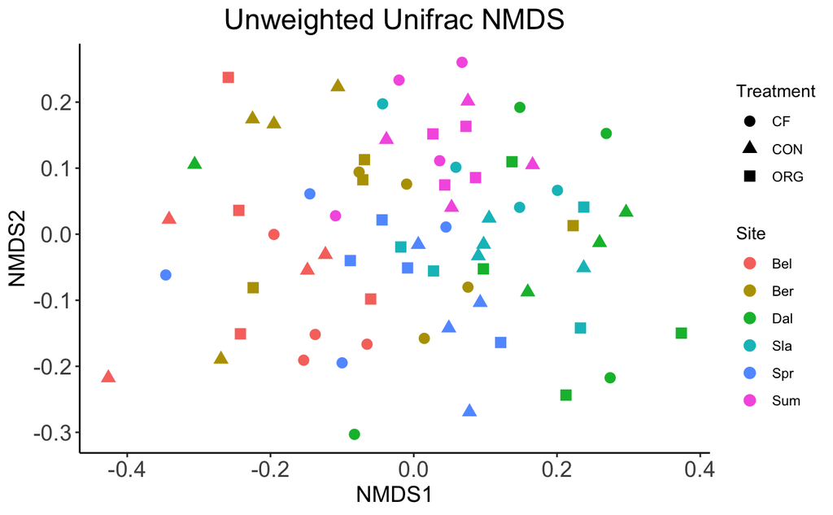

```r
plot_ordination(physeq = bb16S_bac_ML, ordination = ord_nmds, type = "Samples", color = "Site", shape = "Treatment" ) + theme_classic() + ggtitle("Unweighted Unifrac NMDS") + theme(plot.title = element_text(hjust = 0.5, size = 18)) + geom_point(size = 3) + theme(axis.text = element_text(size = 14), axis.title=element_text(size=14))
```

```r
#ggsave("../../Writing/Final_Figs/Unweighted_Unifrac_NMDS.eps")
```

Sampling time 2 (post treatment)

```r
#post-treatment samples
bb16S_bac_ML_A<-subset_samples(bb16S_bac_ML, Timepoint == "A")

#extract data from phyloseq object for post-treatment
sd_adonis<-data.frame(sample_data(bb16S_bac_ML_A))
sd_adonis$Treatment <-as.factor(sd_adonis$Treatment)
sd_adonis$Site <-as.factor(sd_adonis$Site)
dist_wb<-phyloseq::distance(bb16S_bac_ML_A, method =  "wunifrac")
dist_uwb<-phyloseq::distance(bb16S_bac_ML_A, method =  "unifrac")


#w/o strata
#table S4
adonis2(dist_wb ~  Site * Treatment, data= sd_adonis, permutations = 1000)
adonis2(dist_uwb ~  Site * Treatment, data= sd_adonis, permutations = 1000)
#with strata argument
adonis2(dist_wb ~  Site * Treatment, data= sd_adonis, strata = sd_adonis$Site, permutations = 1000)
adonis2(dist_uwb ~  Site * Treatment, data= sd_adonis, strata = sd_adonis$Site, permutations = 1000)

pairwiseAdonis::pairwise.adonis2(dist_uwb ~Treatment, strata = "Site", data = sd_adonis, nperm = 1000)
pairwiseAdonis::pairwise.adonis2(dist_wb ~Treatment, strata = "Site", data = sd_adonis, nperm = 1000)

#ordinations
#weighted Unifrac
ord_nmds<-ordinate(physeq = bb16S_bac_ML_A, method = "NMDS", distance = "wunifrac")
ord_nmds$stress
plot_ordination(physeq = bb16S_bac_ML_A, ordination = ord_nmds, type = "Samples", color = "Site", shape = "Treatment" ) + theme_classic() + ggtitle("Weighted Unifrac NMDS") + theme(plot.title = element_text(hjust = 0.5, size = 18)) + geom_point(size = 3)
#ggsave("../../Writing/Final_Figs/Time2_Weighted_Unifrac_NMDS.pdf")


#unweighted Unifrac
ord_nmds<-ordinate(physeq = bb16S_bac_ML_A, method = "NMDS", distance = "unifrac")
ord_nmds$stress
plot_ordination(physeq = bb16S_bac_ML_A, ordination = ord_nmds, type = "Samples", color = "Site", shape = "Treatment" ) + theme_classic() + ggtitle("Unweighted Unifrac NMDS") + theme(plot.title = element_text(hjust = 0.5, size = 18)) + geom_point(size = 3)
#ggsave("../../Writing/Final_Figs/Time2_Unweighted_Unifrac_NMDS.pdf")
```

create taxa bar plot to display makeup

```r
sort(table(data.frame(tax_table(bb16S_bac_rarefy))$Phylum), decreasing = TRUE)
length(unique(data.frame(tax_table(bb16S_bac_rarefy))$Phylum))

sort(table(data.frame(tax_table(bb16S_bac_rarefy))$Order), decreasing = TRUE)
length(unique(data.frame(tax_table(bb16S_bac_rarefy))$Order))

sort(table(data.frame(tax_table(bb16S_bac_rarefy))$Family), decreasing = TRUE)
length(unique(data.frame(tax_table(bb16S_bac_rarefy))$Family))

plot_bar(subset_samples(bb16S_bac_rarefy, Timepoint == "A"), fill = "Phylum")  + scale_fill_manual(values = col_vector) + geom_bar(stat = "identity")+ coord_flip()
ggsave("../../Writing/Final_Figs/taxabarAfter_2_25_23.eps")

plot_bar(subset_samples(bb16S_bac_rarefy, Timepoint == "B"), fill = "Phylum")  + scale_fill_manual(values = col_vector) + geom_bar(stat = "identity")+ coord_flip()
ggsave("../../Writing/Final_Figs/taxabarBefore_2_25_23.eps")
```

#Core analysis

```r
#create super long color vector
col_vector <- c("#000000", "#FFFF00", "#1CE6FF", "#FF34FF", "#FF4A46", "#008941", "#006FA6", "#A30059",
        "#FFDBE5", "#7A4900", "#0000A6", "#63FFAC", "#B79762", "#004D43", "#8FB0FF", "#997D87",
        "#5A0007", "#809693", "#FEFFE6", "#1B4400", "#4FC601", "#3B5DFF", "#4A3B53", "#FF2F80",
        "#61615A", "#BA0900", "#6B7900", "#00C2A0", "#FFAA92", "#FF90C9", "#B903AA", "#D16100",
        "#DDEFFF", "#000035", "#7B4F4B", "#A1C299", "#300018", "#0AA6D8", "#013349", "#00846F",
        "#372101", "#FFB500", "#C2FFED", "#A079BF", "#CC0744", "#C0B9B2", "#C2FF99", "#001E09",
        "#00489C", "#6F0062", "#0CBD66", "#EEC3FF", "#456D75", "#B77B68", "#7A87A1", "#788D66",
        "#885578", "#FAD09F", "#FF8A9A", "#D157A0", "#BEC459", "#456648", "#0086ED", "#886F4C",

        "#34362D", "#B4A8BD", "#00A6AA", "#452C2C", "#636375", "#A3C8C9", "#FF913F", "#938A81",
        "#575329", "#00FECF", "#B05B6F", "#8CD0FF", "#3B9700", "#04F757", "#C8A1A1", "#1E6E00",
        "#7900D7", "#A77500", "#6367A9", "#A05837", "#6B002C", "#772600", "#D790FF", "#9B9700",
        "#549E79", "#FFF69F", "#201625", "#72418F", "#BC23FF", "#99ADC0", "#3A2465", "#922329",
        "#5B4534", "#FDE8DC", "#404E55", "#0089A3", "#CB7E98", "#A4E804", "#324E72", "#6A3A4C",
        "#83AB58", "#001C1E", "#D1F7CE", "#004B28", "#C8D0F6", "#A3A489", "#806C66", "#222800",
        "#BF5650", "#E83000", "#66796D", "#DA007C", "#FF1A59", "#8ADBB4", "#1E0200", "#5B4E51",
        "#C895C5", "#320033", "#FF6832", "#66E1D3", "#CFCDAC", "#D0AC94", "#7ED379", "#012C58",

        "#7A7BFF", "#D68E01", "#353339", "#78AFA1", "#FEB2C6", "#75797C", "#837393", "#943A4D",
        "#B5F4FF", "#D2DCD5", "#9556BD", "#6A714A", "#001325", "#02525F", "#0AA3F7", "#E98176",
        "#DBD5DD", "#5EBCD1", "#3D4F44", "#7E6405", "#02684E", "#962B75", "#8D8546", "#9695C5",
        "#E773CE", "#D86A78", "#3E89BE", "#CA834E", "#518A87", "#5B113C", "#55813B", "#E704C4",
        "#00005F", "#A97399", "#4B8160", "#59738A", "#FF5DA7", "#F7C9BF", "#643127", "#513A01",
        "#6B94AA", "#51A058", "#A45B02", "#1D1702", "#E20027", "#E7AB63", "#4C6001", "#9C6966",
        "#64547B", "#97979E", "#006A66", "#391406", "#F4D749", "#0045D2", "#006C31", "#DDB6D0",
        "#7C6571", "#9FB2A4", "#00D891", "#15A08A", "#BC65E9", "#FFFFFE", "#C6DC99", "#203B3C",
        "#671190", "#6B3A64", "#F5E1FF", "#FFA0F2", "#CCAA35", "#374527", "#8BB400", "#797868",
        "#C6005A", "#3B000A", "#C86240", "#29607C", "#402334", "#7D5A44", "#CCB87C", "#B88183",
        "#AA5199", "#B5D6C3", "#A38469", "#9F94F0", "#A74571", "#B894A6", "#71BB8C", "#00B433",
        "#789EC9", "#6D80BA", "#953F00", "#5EFF03", "#E4FFFC", "#1BE177", "#BCB1E5", "#76912F",
        "#003109", "#0060CD", "#D20096", "#895563", "#29201D", "#5B3213", "#A76F42", "#89412E",
        "#1A3A2A", "#494B5A", "#A88C85", "#F4ABAA", "#A3F3AB", "#00C6C8", "#EA8B66", "#958A9F",
        "#BDC9D2", "#9FA064", "#BE4700", "#658188", "#83A485", "#453C23", "#47675D", "#3A3F00",
        "#061203", "#DFFB71", "#868E7E", "#98D058", "#6C8F7D", "#D7BFC2", "#3C3E6E", "#D83D66",
        "#2F5D9B", "#6C5E46", "#D25B88", "#5B656C", "#00B57F", "#545C46", "#866097", "#365D25",
        "#252F99", "#00CCFF", "#674E60", "#FC009C", "#92896B")
```

calculate core at genus and asv level using rarefied data

```r
#calculate core at genus level
#325 genera
bb16S_bac_rarefy_tax_genus<-tax_glom(physeq = bb16S_bac_rarefy, taxrank = "Genus", NArm = F)
#calculate core
core_genus<-taxa_core(phyloseq_obj = bb16S_bac_rarefy_tax_genus, treatment = "Site", frequency = 1, abundance_threshold = 0.0001)
core_genus<-taxa_core(phyloseq_obj = core_genus, frequency = 0.5, abundance_threshold = 0.0001)

otu_genus_core <- data.frame(otu_table(core_genus))
tax_genus_core <- data.frame(tax_table(core_genus))
samp_data_genus_core <- data.frame(sample_data(core_genus))

percent_abund<-(otu_genus_core[,]/1100)

write.csv(percent_abund, "/Users/gordoncuster/Desktop/Git_Projects/BeeBread/Writing/core_genera_percent_abund.csv")

#write.csv(otu_genus_core, "/Users/gordoncuster/Desktop/Git_Projects/BeeBread/Writing/otu_genus_core.csv")
#write.csv(tax_genus_core, "/Users/gordoncuster/Desktop/Git_Projects/BeeBread/Writing/tax_genus_core.csv")
#write.csv(samp_data_genus_core, "/Users/gordoncuster/Desktop/Git_Projects/BeeBread/Writing/samp_data_genus_core.csv")

#table taxonomic info of core genera
table(data.frame(tax_table(core_genus))$Order)
table(data.frame(tax_table(core_genus))$Genus)
#percent of genera assigned to core
14/325
#percent of reads accounted for by the core genera
sum(sample_sums(core_genus))/sum(sample_sums(bb16S_bac_rarefy))



#extract sequence of core genera and export for tree building
core_genus_names<-rownames(tax_table(core_genus))
core_genera_rep_seq<-seq_df_w_OTUID[seq_df_w_OTUID$OTUID %in% str_split(core_genus_names, pattern = "_", 2, simplify = T)[,2],]
taxa_df<-data.frame(taxa)
core_genera_tax <- taxa_df[rownames(taxa_df) %in% core_genera_rep_seq$Sequence,]
core_genera_tax$Sequence <- rownames(core_genera_tax)
merged_tax_core_genera_rep_seq<-full_join(core_genera_tax, core_genera_rep_seq)

#write.csv(merged_tax_core_genera_rep_seq, "/Users/gordoncuster/Desktop/Git_Projects/BeeBread/Writing/Core_genera_taxa_rep_seq.csv")
#write.csv(core_genera_rep_seq, "/Users/gordoncuster/Desktop/Git_Projects/BeeBread/Writing/Core_Genera_Rep_Seqs.csv")
#write.csv(core_genera_tax, "/Users/gordoncuster/Desktop/Git_Projects/BeeBread/Writing/Core_Genera_tax.csv")
```

Core Genus

```r
#core asv adonis
tab_adonis<-data.frame(otu_table(core_genus))
sd_adonis<-data.frame(sample_data(core_genus))
sd_adonis$Treatment <-as.factor(sd_adonis$Treatment)
sd_adonis$Site <-as.factor(sd_adonis$Site)
dist_core_w_genus<-phyloseq::distance(core_genus, method =  "wunifrac")
dist_core_uw_genus<-phyloseq::distance(core_genus, method =  "unifrac")

#weighted unifrac
adonis2(dist_core_w_genus ~  Site * Treatment * Timepoint, data= sd_adonis, strata = sd_adonis$Site, permutations = 1000)
#unweighted unifrac
adonis2(dist_core_uw_genus ~  Site * Treatment * Timepoint, data= sd_adonis, strata = sd_adonis$Site, permutations = 1000)

#ordinations
#weighted Unifrac
ord_nmds<-ordinate(physeq = core_genus, method = "NMDS", distance = "wunifrac")
ord_nmds$stress
plot_ordination(physeq = core_genus, ordination = ord_nmds, type = "Samples", color = "Site", shape = "Treatment" ) + theme_classic() + ggtitle("Core Genera Weighted Unifrac NMDS") + theme(plot.title = element_text(hjust = 0.5, size = 18)) + geom_point(size = 3)  + theme(axis.text = element_text(size = 14), axis.title=element_text(size=14))
ggsave("../../Writing/Final_Figs/CoreGenus_Weighted_Unifrac_NMDS.eps")
#strongest grouping by Site. Time point also has a smaller effect, but these groupings are more clear than in the CAP ordination. There are several outlier samples that ordinate far to the right on the NMDS1 axis.

#unweighted Unifrac
ord_nmds<-ordinate(physeq = core_genus, method = "NMDS", distance = "unifrac")
ord_nmds$stress
plot_ordination(physeq = core_genus, ordination = ord_nmds, type = "Samples", color = "Site", shape = "Treatment" ) + theme_classic() + ggtitle("Core Genera Unweighted Unifrac NMDS") + theme(plot.title = element_text(hjust = 0.5, size = 18)) + geom_point(size = 3) + theme(axis.text = element_text(size = 14), axis.title=element_text(size=14))
ggsave("../../Writing/Final_Figs/CoreGenus_Unweighted_Unifrac_NMDS.eps")
```

Core genus at time points 1 and 2

```r
core_genus_A <- subset_samples(core_genus, Timepoint == "A")

#core asv adonis
tab_adonis<-data.frame(otu_table(core_genus_A))
sd_adonis<-data.frame(sample_data(core_genus_A))
sd_adonis$Treatment <-as.factor(sd_adonis$Treatment)
sd_adonis$Site <-as.factor(sd_adonis$Site)
dist_core_w_genus<-phyloseq::distance(core_genus_A, method =  "wunifrac")
dist_core_uw_genus<-phyloseq::distance(core_genus_A, method =  "unifrac")

#weighted unifrac
adonis2(dist_core_w_genus ~  Site * Treatment, data= sd_adonis, strata = sd_adonis$Site, permutations = 1000)
#unweighted unifrac
adonis2(dist_core_uw_genus ~  Site * Treatment, data= sd_adonis, strata = sd_adonis$Site, permutations = 1000)


core_genus_B <- subset_samples(core_genus, Timepoint == "B")

#core asv adonis
tab_adonis<-data.frame(otu_table(core_genus_B))
sd_adonis<-data.frame(sample_data(core_genus_B))
sd_adonis$Treatment <-as.factor(sd_adonis$Treatment)
sd_adonis$Site <-as.factor(sd_adonis$Site)
dist_core_w_genus<-phyloseq::distance(core_genus_B, method =  "wunifrac")
dist_core_uw_genus<-phyloseq::distance(core_genus_B, method =  "unifrac")

#weighted unifrac
adonis2(dist_core_w_genus ~  Site * Treatment, data= sd_adonis, strata = sd_adonis$Site, permutations = 1000)
#unweighted unifrac
adonis2(dist_core_uw_genus ~  Site * Treatment, data= sd_adonis, strata = sd_adonis$Site, permutations = 1000)
```

Visualization of core microbiome using barplot

```r
#pull out core genera names
core_genus_names<-rownames(tax_table(core_genus))
genus_OTU_table<-data.frame(t(otu_table(bb16S_bac_rarefy_tax_genus)))
#check orientation of otu table
rownames(genus_OTU_table)
#add columns corresponding to core status, % sites, % reads
genus_OTU_table$Core <- NA
for(i in 1:nrow(genus_OTU_table)){
  if(rownames(genus_OTU_table)[i] %in% core_genus_names == T){
  genus_OTU_table[i,]$Core <- "Core"
  } else{
  genus_OTU_table[i,]$Core <- "NonCore"
  }
}

#Prevalence column
genus_OTU_table$prev <- NA
for(i in 1:nrow(genus_OTU_table)){
  genus_OTU_table[i,]$prev<-table(genus_OTU_table[i,(1:69)] > 0)["TRUE"]/ 69}

#proportional abundance
genus_OTU_table$abund <- NA
  for(i in 1:nrow(genus_OTU_table)){
  genus_OTU_table[i,]$abund <- rowSums(genus_OTU_table[i,c(1:69)])/sum(colSums(genus_OTU_table[,c(1:69)]))
  }

dat<-genus_OTU_table[,c(70:72)]
dat$otu <- as.factor(rownames(dat))
dat$otu <- reorder(dat$otu, -dat$prev )
dat$Phylum <- as.factor(data.frame(tax_table(bb16S_bac_rarefy_tax_genus))$Phylum)
dat$number <- 1:nrow(dat)

ggplot(dat, aes(x = otu, y=prev, fill = Phylum)) +
  geom_bar(stat="identity") + scale_fill_manual(values=col_vector) + theme_classic() +
  theme(axis.title.x=element_blank(),
        axis.text.x=element_blank(),
        axis.ticks.x=element_blank()) + ylab("Prevalance") + theme(legend.position = "none")
#ggsave("../../Writing/Final_Figs/core_prev_owlegend.eps")

ggplot(dat, aes(x = otu, y=abund,  fill = Phylum)) +
  geom_bar(stat="identity") + scale_fill_manual(values=col_vector) + theme_classic()  + scale_y_reverse() + theme(axis.text.x = element_text(size = 4 , angle = 45, hjust = 1))
#ggsave("../../Writing/Final_Figs/core_abund.eps")

ggplot(dat, aes(x = otu, y=abund,  fill = Phylum)) +
  geom_bar(stat="identity") + scale_fill_manual(values=col_vector) + theme_classic()  + scale_y_reverse() + theme(axis.text.x = element_text(size = 4 , angle = 45, hjust = 1)) + theme(legend.position = "none") + ylab("Proportional Abundance") + xlab("OTU ID")
#ggsave("../../Writing/Final_Figs/core_abund_wolegend.eps")


#color by core inclusion

ggplot(dat, aes(x = otu, y=prev, fill = Core)) +
  geom_bar(stat="identity") + scale_fill_manual(values=c("#88CCEE", "#999933")) +
  theme_classic() +
  theme(axis.title.x=element_blank(),
        axis.text.x=element_blank(),
        axis.ticks.x=element_blank()) + ylab("Prevalance") + theme(legend.position = "none")  + theme(axis.text.y = element_text(size=12), axis.title.y = element_text(size = 16))
ggsave("../../Writing/Final_Figs/core_prev_owlegend_Core.eps")

ggplot(dat, aes(x = otu, y=abund,  fill = Core)) +
  geom_bar(stat="identity") + scale_fill_manual(values=c("#88CCEE", "#999933")) +
  theme_classic()  + scale_y_reverse() + theme(axis.text.x = element_text(size = 4 , angle = 45, hjust = 1, face = "bold"))+ theme( axis.text.x=element_blank(), axis.ticks.x=element_blank())  + theme(axis.text.y = element_text(size=12), axis.title.y = element_text(size = 16))
ggsave("../../Writing/Final_Figs/core_abund_Core.eps")

ggplot(dat, aes(x = otu, y=abund,  fill = Core)) +
  geom_bar(stat="identity") +  scale_fill_manual(values=c("#88CCEE", "#999933")) +
  theme_classic()  + scale_y_reverse() +# theme(axis.text.x = element_text(size = 4 , angle = 45, hjust = 1)) +
theme(legend.position = "none") + ylab("Proportional Abundance") + xlab("OTU") + theme(axis.text.x=element_blank(), axis.ticks.x=element_blank()) + theme(axis.text.y = element_text(size=12), axis.title.y = element_text(size = 16))
ggsave("../../Writing/Final_Figs/core_abund_wolegend_Core.eps")
```

#### Acidophilic bacteria

analysis of lactic acid bacteria and acetic acid bacteria at time point 2 (following application)

```r
bb16S_bac_ML_A<-subset_samples(bb16S_bac_ML, Timepoint == "A")
#ACETO
#36 taxa
acetobacter <- subset_taxa(bb16S_bac_ML_A, Family =="Acetobacteraceae")
acetobacter_glomed<- tax_glom(acetobacter, taxrank = "Family")


#anova for all taxa combined
dat<-data.frame(otu_table(acetobacter_glomed))
samp_d<-data.frame(sample_data(acetobacter_glomed))
merged_dat<-cbind(dat, samp_d)
#check to make sure md and otu table are in same order. All should be true.
table(merged_dat$X == rownames(merged_dat))
##mod<-aov(OTU_40 ~ Treatment, data = merged_dat)
#summary(mod)
#plot(residuals(mod))
#boxplot(merged_dat$OTU_40 ~ merged_dat$Treatment)

#baruta for individual taxa
aceto_df <- cbind(data.frame(otu_table(acetobacter)), data.frame(sample_data(acetobacter)))
table(aceto_df$X == rownames(aceto_df))
boxplot(aceto_df$OTU_82 ~ aceto_df$Treatment)
View(tax_table(acetobacter))
#otu 82 ID'ed by baruta. More abundant in ORG. Taxonomy for this taxa "Acetobacteraceae, Bombella"

for(i in 1:length(names(data.frame(otu_table(acetobacter))))){
  boxplot(unlist(aceto_df[i]) ~ aceto_df$Treatment)
}

#very zero inflated so we will not use anova.
#for(i in 1:length(names(data.frame(otu_table(acetobacter))))){
#  mod<-aov(unlist(aceto_df[i]) ~ aceto_df$Treatment)
#  summary(mod)
#  print(summary(mod))
#  print(names(aceto_df[i]))
#}

for(i in 1:length(names(data.frame(otu_table(acetobacter))))){
  mod<-kruskal.test(unlist(aceto_df[i]) ~ aceto_df$Treatment)
  print(mod)
  print(names(aceto_df[i]))
}


pairwise.wilcox.test(aceto_df$OTU_122, aceto_df$Treatment)
ggplot(aceto_df, aes(x = Treatment, y = OTU_122, color = Treatment)) + geom_boxplot()  + theme_classic()  + theme(axis.text = element_text(size = 14), axis.title=element_text(size=14))

pairwise.wilcox.test(aceto_df$OTU_282, aceto_df$Treatment)
ggplot(aceto_df, aes(x = Treatment, y = OTU_282, color = Treatment)) + geom_boxplot()  + theme_classic()  + theme(axis.text = element_text(size = 14), axis.title=element_text(size=14))

#ggsave("/Users/gordoncuster/Desktop/Git_Projects/BeeBread/Writing/Final_Figs/OTU_282_After_Treatment.eps")
```

repeat analysis with glommed at genus level

```r
acetobacter_glomed_genus<- tax_glom(acetobacter, taxrank = "Genus")
#anova for all taxa combined
dat<-data.frame(otu_table(acetobacter_glomed_genus))
samp_d<-data.frame(sample_data(acetobacter_glomed_genus))
merged_dat<-cbind(dat, samp_d)
#check to make sure md and otu table are in same order. All should be true.
table(merged_dat$X == rownames(merged_dat))
#pull out data
aceto_df <- cbind(data.frame(otu_table(acetobacter_glomed_genus)), data.frame(sample_data(acetobacter_glomed_genus)))
table(aceto_df$X == rownames(aceto_df))

for(i in 1:length(names(data.frame(otu_table(acetobacter_glomed_genus))))){
  mod<-kruskal.test(unlist(aceto_df[i]) ~ aceto_df$Treatment)
  print(mod)
  print(names(aceto_df[i]))
}


for(i in 1:length(names(data.frame(otu_table(acetobacter_glomed_genus))))){
 mod<-aov(unlist(aceto_df[i]) ~ aceto_df$Treatment)
 summary(mod)
  print(summary(mod))
  print(names(aceto_df[i]))
}

ggplot(aceto_df, aes(x = Treatment, y = OTU_82, color = Treatment)) + geom_boxplot()  + theme_classic()  + theme(axis.text = element_text(size = 14), axis.title=element_text(size=14))

tax_table(acetobacter_glomed_genus)
```

```r
##LACTO

#75 taxa
lactobac <- subset_taxa(bb16S_bac_ML_A, Order =="Lactobacillales")
lactobac_glomed <- tax_glom(lactobac, taxrank = "Order")

dat<-data.frame(otu_table(lactobac_glomed))
samp_d<-data.frame(sample_data(lactobac_glomed))
merged_dat<-cbind(dat, samp_d)
#check to make sure md and otu table are in same order. All should be true.
table(merged_dat$X == rownames(merged_dat))

lacto_df <- cbind(data.frame(otu_table(lactobac)), data.frame(sample_data(lactobac)))
table(lacto_df$X == rownames(lacto_df))
boxplot(lacto_df$OTU_530 ~ lacto_df$Treatment)
View(tax_table(lactobac))



for(i in 1:length(names(data.frame(otu_table(lactobac))))){
  boxplot(unlist(lacto_df[i]) ~ lacto_df$Treatment)
}

for(i in 1:length(names(data.frame(otu_table(lactobac))))){
   mod<-kruskal.test(unlist(lacto_df[i]) ~ lacto_df$Treatment)
  print(mod)
  print(names(lacto_df[i]))
}

pairwise.wilcox.test(lacto_df$OTU_568, lacto_df$Treatment)
```

calculate mean abundance of dominant groups

```r
phy_ps <- tax_glom(bb16S_bac_rarefy, taxrank = "Phylum")
#phylum counts
table(data.frame(tax_table(bb16S_bac_rarefy))$Phylum)
phy_ps<- transform_sample_counts(phy_ps, function(x) x / sum(x))
phylum_df<-data.frame(otu_table(phy_ps))
rownames(tax_table(phy_ps)) == names(phylum_df)
names(phylum_df) <- tax_table(phy_ps)[,2]
apply(phylum_df, 2, mean)
apply(phylum_df, 2, sd)



order_ps <- tax_glom(bb16S_bac_rarefy, taxrank = "Order")
#phylum counts
sort(table(data.frame(tax_table(bb16S_bac_rarefy))$Order))
order_ps<- transform_sample_counts(order_ps, function(x) x / sum(x))
order_df<-data.frame(otu_table(order_ps))
rownames(tax_table(order_ps)) == names(order_df)
names(order_df) <- tax_table(order_ps)[,4]
apply(order_df, 2, mean)
apply(order_df, 2, sd)
```

https://stackoverflow.com/questions/61796484/stacked-bar-chart-with-count-above-and-below-x-axis